# Survival Analysis in R

# Part 0: Reference

- The full source code can be found at: https://github.com/zabore/tutorials/blob/master/survival_analysis_in_r_tutorial.Rmd
- http://www.sthda.com/english/wiki/survival-analysis-basics

# Part 1: Introduction to Survival Analysis

The following tutorial papers can be helpful for additional reading:

> Clark, T., Bradburn, M., Love, S., & Altman, D. (2003). Survival analysis part I: Basic concepts and first analyses. 232-238. ISSN 0007-0920.

> M J Bradburn, T G Clark, S B Love, & D G Altman. (2003). Survival Analysis Part II: Multivariate data analysis – an introduction to concepts and methods. British Journal of Cancer, 89(3), 431-436.

> Bradburn, M., Clark, T., Love, S., & Altman, D. (2003). Survival analysis Part III: Multivariate data analysis – choosing a model and assessing its adequacy and fit. 89(4), 605-11.

> Clark, T., Bradburn, M., Love, S., & Altman, D. (2003). Survival analysis part IV: Further concepts and methods in survival analysis. 781-786. ISSN 0007-0920.

## What is survival data?

Time-to-event data that consist of a distinct start time and end time.

Examples from cancer

- Time from surgery to death
- Time from start of treatment to progression
- Time from response to recurrence

## Examples from other fields

Time-to-event data are common in many fields including, but not limited to

- Time from HIV infection to development of AIDS
- Time to heart attack
- Time to onset of substance abuse
- Time to initiation of sexual activity
- Time to machine malfunction

## Aliases for survival analysis

Because survival analysis is common in many other fields, it also goes by other names

- Reliability analysis
- Duration analysis
- Event history analysis
- Time-to-event analysis

## The lung dataset

The `lung` dataset is available from the `survival` package in `R`. The data contain subjects with advanced lung cancer from the North Central Cancer Treatment Group. Some variables we will use to demonstrate methods today include

- time: Survival time in days
- status: censoring status 1=censored, 2=dead
- sex: Male=1 Female=2

## What is censoring?

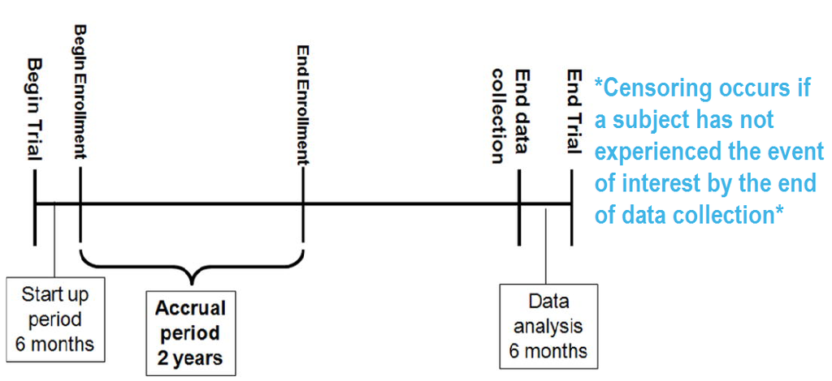

> RICH JT, NEELY JG, PANIELLO RC, VOELKER CCJ, NUSSENBAUM B, WANG EW. A PRACTICAL GUIDE TO UNDERSTANDING KAPLAN-MEIER CURVES. Otolaryngology head and neck surgery: official journal of American Academy of Otolaryngology Head and Neck Surgery. 2010;143(3):331-336. doi:10.1016/j.otohns.2010.05.007.

## Types of censoring

A subject may be censored due to:

- Lost to follow-up
- Withdrawal from study
- No event by end of fixed study period

Specifically these are examples of **right** censoring.

Left censoring and interval censoring are also possible, and methods exist to analyze this type of data, but this training will be limited to right censoring.

## Censored survival data

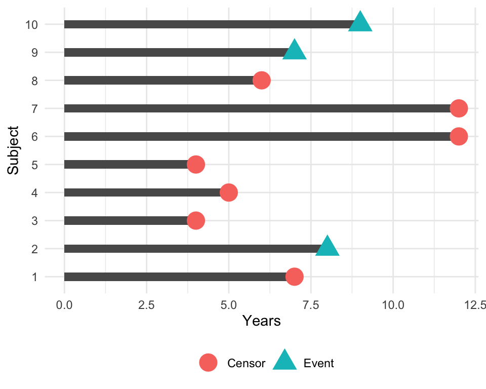

In this example, how would we compute the proportion who are event-free at 10 years?

Subjects 6 and 7 were **event-free at 10 years**. Subjects 2, 9, and 10 had the **event before 10 years**. Subjects 1, 3, 4, 5, and 8 were **censored before 10 years**, so we don’t know whether they had the event or not by 10 years - how do we incorporate these subjects into our estimate?

## Distribution of follow-up time

- Censored subjects still provide information so must be appropriately included in the analysis
- Distribution of follow-up times is skewed, and may differ between censored patients and those with events
- Follow-up times are always positive

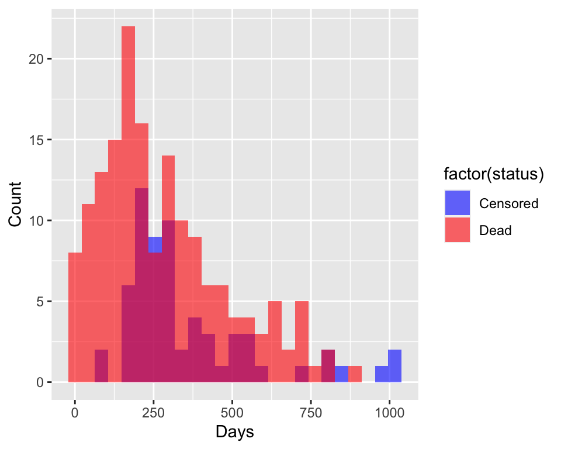

## Components of survival data

For subject $i$:

1. Event time $T_i$
2. Censoring time $C_i$
3. Event indicator $\delta_i$:
   - 1 if event observed (i.e. $T_i \leq C_i$)
   - 0 if censored (i.e. $T_i > C_i$)
4. Observed time $Y_i = \min(T_i, C_i)$

The observed times and an event indicator are provided in the `lung` data

- time: Survival time in days
- status: censoring status 1=censored, 2=dead

| inst | time | status | age | sex | ph.ecog | ph.karno | pat.karno | meal.cal | wt.loss |
| --- | --- | --- | --- | --- | --- | --- | --- | --- | --- |
| 3 | 306 | 2 | 74 | 1 | 1 | 90 | 100 | 1175 | NA |
| 3 | 455 | 2 | 68 | 1 | 0 | 90 | 90 | 1225 | 15 |
| 3 | 1010 | 1 | 56 | 1 | 0 | 90 | 90 | NA | 15 |
| 5 | 210 | 2 | 57 | 1 | 1 | 90 | 60 | 1150 | 11 |
| 1 | 883 | 2 | 60 | 1 | 0 | 100 | 90 | NA | 0 |
| 12 | 1022 | 1 | 74 | 1 | 1 | 50 | 80 | 513 | 0 |

## Dealing with dates in R

Data will often come with start and end dates rather than pre-calculated survival times. The first step is to make sure these are formatted as dates in R.

Let’s create a small example dataset with variables `sx_date` for surgery date and `last_fup_date` for the last follow-up date.

```r
date_ex <-
  tibble(
    sx_date = c("2007-06-22", "2004-02-13", "2010-10-27"),
    last_fup_date = c("2017-04-15", "2018-07-04", "2016-10-31")
    )

date_ex
```

```
## # A tibble: 3 × 2
##   sx_date    last_fup_date
##   <chr>      <chr>
## 1 2007-06-22 2017-04-15
## 2 2004-02-13 2018-07-04
## 3 2010-10-27 2016-10-31
```

We see these are both character variables, which will often be the case, but we need them to be formatted as dates.

## Formatting dates - base R

```r
date_ex %>%
  mutate(
    sx_date = as.Date(sx_date, format = "%Y-%m-%d"),
    last_fup_date = as.Date(last_fup_date, format = "%Y-%m-%d")
    )
```

```
## # A tibble: 3 × 2
##   sx_date    last_fup_date
##   <date>     <date>
## 1 2007-06-22 2017-04-15
## 2 2004-02-13 2018-07-04
## 3 2010-10-27 2016-10-31
```

- Note that in base `R` the format must include the separator as well as the symbol. e.g. if your date is in format m/d/Y then you would need `format = "%m/%d/%Y"`
- See a full list of date format symbols at https://www.statmethods.net/input/dates.html

## Formatting dates - lubridate package

We can also use the `lubridate` package to format dates. In this case, use the `ymd` function

```r
date_ex %>%
  mutate(
    sx_date = ymd(sx_date),
    last_fup_date = ymd(last_fup_date)
    )
```

```
## # A tibble: 3 × 2
##   sx_date    last_fup_date
##   <date>     <date>
## 1 2007-06-22 2017-04-15
## 2 2004-02-13 2018-07-04
## 3 2010-10-27 2016-10-31
```

- Note that unlike the base `R` option, the separators do not need to be specified
- The help page for `?dmy` will show all format options.

## Calculating survival times - base R

Now that the dates formatted, we need to calculate the difference between start and end time in some units, usually months or years. In base `R`, use `difftime` to calculate the number of days between our two dates and convert it to a numeric value using `as.numeric`. Then convert to years by dividing by `365.25`, the average number of days in a year.

```r
date_ex %>%
  mutate(
    os_yrs =
      as.numeric(
        difftime(last_fup_date,
                 sx_date,
                 units = "days")) / 365.25
    )
```

```
## # A tibble: 3 × 3
##   sx_date    last_fup_date os_yrs
##   <date>     <date>         <dbl>
## 1 2007-06-22 2017-04-15      9.82
## 2 2004-02-13 2018-07-04     14.4
## 3 2010-10-27 2016-10-31      6.01
```

## Calculating survival times - lubridate

Using the `lubridate` package, the operator `%--%` designates a time interval, which is then converted to the number of elapsed **seconds** using `as.duration` and finally converted to years by dividing by `dyears(1)`, which gives the number of **seconds** in a year.

```r
date_ex %>%
  mutate(
    os_yrs =
      as.duration(sx_date %--% last_fup_date) / dyears(1)
    )
```

```
## # A tibble: 3 × 3
##   sx_date    last_fup_date os_yrs
##   <date>     <date>         <dbl>
## 1 2007-06-22 2017-04-15      9.82
## 2 2004-02-13 2018-07-04     14.4
## 3 2010-10-27 2016-10-31      6.01
```

## Event indicator

For the components of survival data I mentioned the event indicator:

Event indicator $\delta_i$:

- 1 if event observed (i.e. $T_i \leq C_i$)
- 0 if censored (i.e. $T_i > C_i$)

However, in `R` the `Surv` function will also accept TRUE/FALSE (TRUE = event) or 1/2 (2 = event).

In the `lung` data, we have:

- status: censoring status 1=censored, 2=dead

## Survival function

The probability that a subject will survive beyond any given specified time

$$S(t) = Pr(T>t) = 1 - F(t)$$

- $S(t)$: survival function
- $F(t) = Pr(T \leq t)$: cumulative distribution function

In theory the survival function is smooth; in practice we observe events on a discrete time scale.

## Survival probability

- **Survival probability** at a certain time, $S(t)$, is a conditional probability of surviving beyond that time, given that an individual has survived just prior to that time.
- Can be estimated as the number of patients who are alive without loss to follow-up at that time, divided by the number of patients who were alive just prior to that time
- The **Kaplan-Meier** estimate of survival probability is the product of these conditional probabilities up until that time
- At time 0, the survival probability is 1, i.e. $S(0) = 1$

## Creating survival objects

The Kaplan-Meier method is the most common way to estimate survival times and probabilities. It is a non-parametric approach that results in a step function, where **there is a step down each time an event occurs**.

- The `Surv` function from the `survival` package creates a survival object for use as the response in a model formula. There will be one entry for each subject that is the survival time, which is followed by a `+` if the subject was censored. Let’s look at the first 10 observations:

```r
Surv(lung$time, lung$status)[1:10]
```

```
##  [1]  306   455  1010+  210   883  1022+  310   361   218   166
```

## Estimating survival curves with the Kaplan-Meier method

- The `survfit` function creates survival curves based on a formula. Let’s generate the overall survival curve for the entire cohort, assign it to object `f1`, and look at the `names` of that object:

```r
f1 <- survfit(Surv(time, status) ~ 1, data = lung)
names(f1)
```

```
##  [1] "n"         "time"      "n.risk"    "n.event"   "n.censor"  "surv"
##  [7] "std.err"   "cumhaz"    "std.chaz"  "type"      "logse"     "conf.int"
## [13] "conf.type" "lower"     "upper"     "call"
```

Some key components of this `survfit` object that will be used to create survival curves include:

- `time`, which contains the start and endpoints of each time interval
- `surv`, which contains the survival probability corresponding to each `time`

## Kaplan-Meier plot - base R

Now we plot the `survfit` object in base `R` to get the Kaplan-Meier plot.

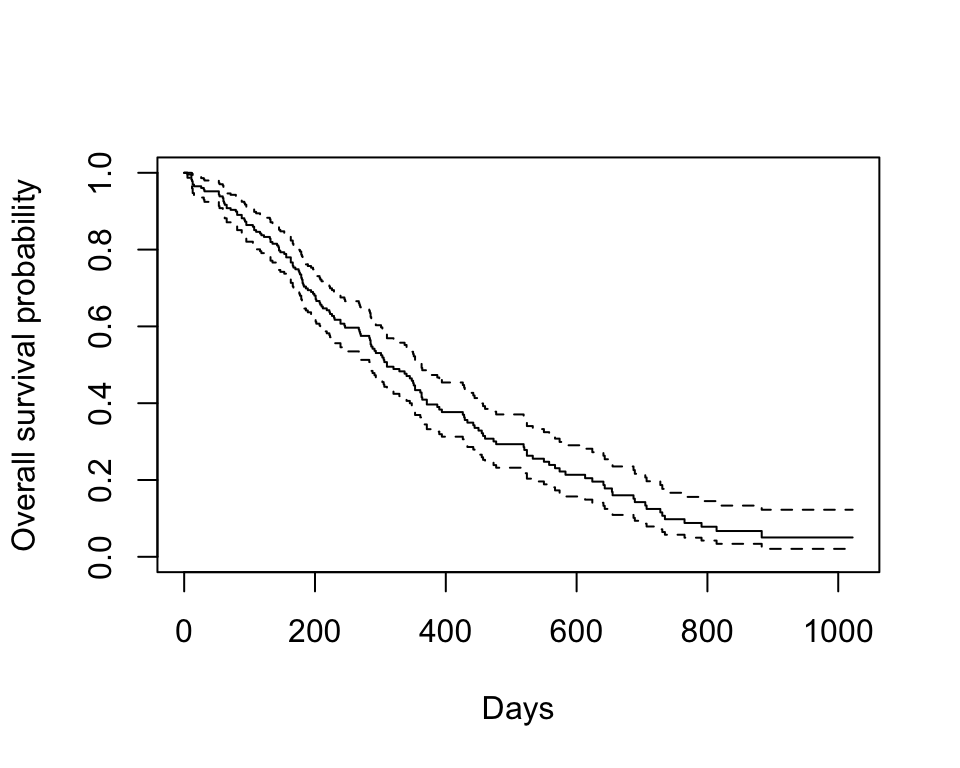

```r
plot(survfit(Surv(time, status) ~ 1, data = lung),
     xlab = "Days",
     ylab = "Overall survival probability")
```

- The default plot in base `R` shows the step function (solid line) with associated confidence intervals (dotted lines)
- Horizontal lines represent survival duration for the interval
- An interval is terminated by an event
- The height of vertical lines show the change in cumulative probability
- Censored observations, indicated by tick marks, reduce the cumulative survival between intervals. (*Note* the tick marks for censored patients are not shown by default, but could be added using the option `mark.time = TRUE`)

## Kaplan-Meier plot - ggsurvplot

Alternatively, the `ggsurvplot` function from the `survminer` package is built on `ggplot2`, and can be used to create Kaplan-Meier plots. Checkout the [cheatsheet](https://rpkgs.datanovia.com/survminer/survminer_cheatsheet.pdf) for the `survminer` package.

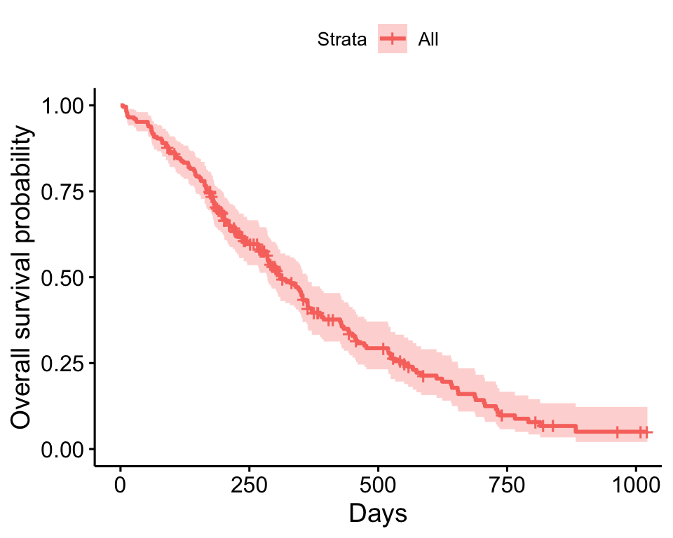

```r
ggsurvplot(
    fit = survfit(Surv(time, status) ~ 1, data = lung),
    xlab = "Days",
    ylab = "Overall survival probability")
```

- The default plot using `ggsurvplot` shows the step function (solid line) with associated confidence bands (shaded area).
- The tick marks for censored patients are shown by default, somewhat obscuring the line itself in this example, and could be supressed using the option `censor = FALSE`

## Estimating $x$-year survival

One quantity often of interest in a survival analysis is the probability of surviving beyond a certain number ($x$) of years.

For example, to estimate the probability of survivng to $1$ year, use `summary` with the `times` argument (*Note* the `time` variable in the `lung` data is actually in days, so we need to use `times = 365.25`)

```r
summary(survfit(Surv(time, status) ~ 1, data = lung), times = 365.25)
```

```
## Call: survfit(formula = Surv(time, status) ~ 1, data = lung)
##
##  time n.risk n.event survival std.err lower 95% CI upper 95% CI
##   365     65     121    0.409  0.0358        0.345        0.486
```

We find that the $1$-year probability of survival in this study is 41%.

The associated lower and upper bounds of the 95% confidence interval are also displayed.

## $x$-year survival and the survival curve

The $1$-year survival probability is the point on the y-axis that corresponds to $1$ year on the x-axis for the survival curve.

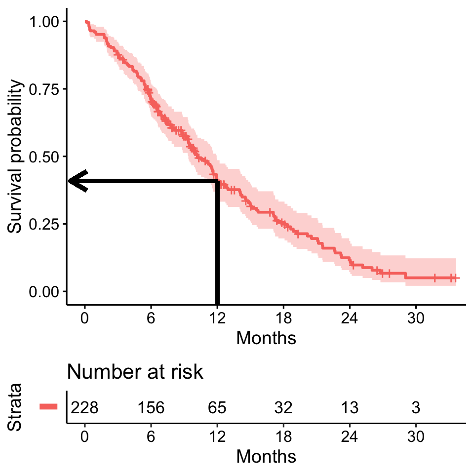

## $x$-year survival is often estimated incorrectly

What happens if you use a “naive” estimate?

121 of the 228 patients died by $1$ year so:

$$\Big(1 - \frac{121}{228}\Big) \times 100 = 47\%$$
- You get an **incorrect** estimate of the $1$-year probability of survival when you ignore the fact that 42 patients were censored before $1$ year.

- Recall the **correct** estimate of the $1$-year probability of survival was 41%.

## Impact on $x$-year survival of ignoring censoring

- Imagine two studies, each with 228 subjects. There are 165 deaths in each study. No censoring in one (orange line), 63 patients censored in the other (blue line)
- Ignoring censoring leads to an **overestimate** of the overall survival probability, because the censored subjects only contribute information for **part** of the follow-up time, and then fall out of the risk set, thus pulling down the cumulative probability of survival

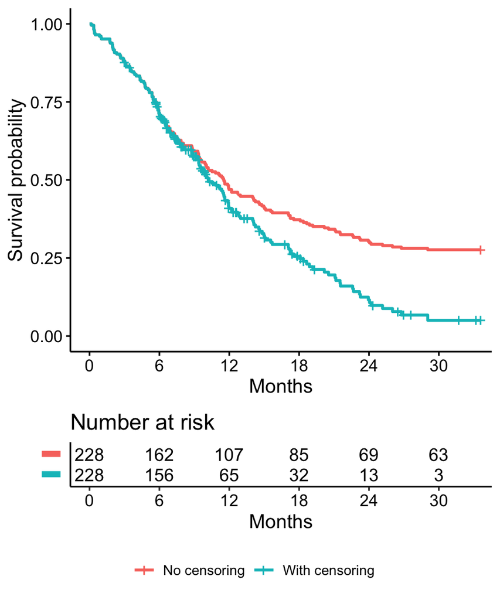

## Estimating median survival time

Another quantity often of interest in a survival analysis is the average survival time, which we quantify using the median. Survival times are not expected to be normally distributed so the mean is not an appropriate summary.

We can obtain this directly from our `survfit` object

```r
survfit(Surv(time, status) ~ 1, data = lung)
```

```
## Call: survfit(formula = Surv(time, status) ~ 1, data = lung)
##
##       n  events  median 0.95LCL 0.95UCL
##     228     165     310     285     363
```

We see the median survival time is 310 days The lower and upper bounds of the 95% confidence interval are also displayed.

## Median survival time and the survival curve

Median survival is the time corresponding to a survival probability of $0.5$:

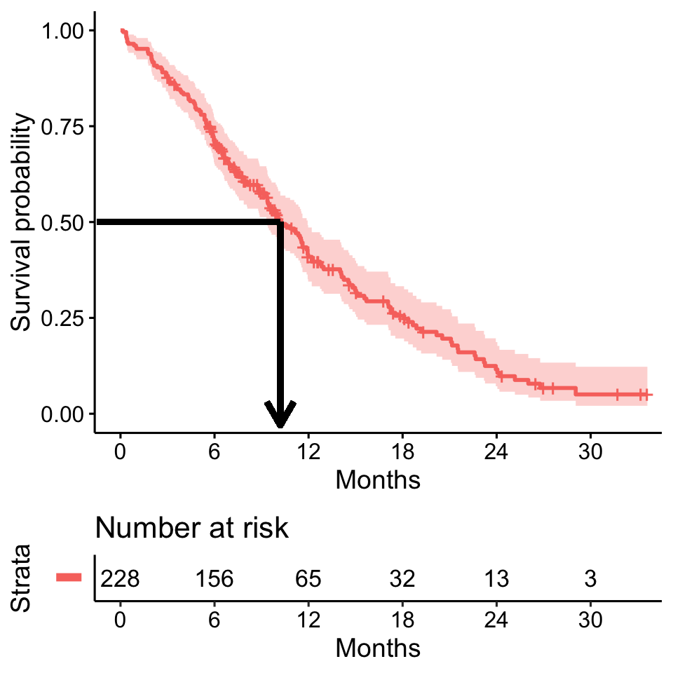

## Median survival is often estimated incorrectly

What happens if you use a “naive” estimate?

Summarize the median survival time among the 165 patients who died

```r
lung %>%
  filter(status == 2) %>%
  summarize(median_surv = median(time))
```

```
##   median_surv
## 1         226
```

- You get an **incorrect** estimate of median survival time of 226 days when you ignore the fact that censored patients also contribute follow-up time.
- Recall the **correct** estimate of median survival time is 310 days.

## Impact on median survival of ignoring censoring

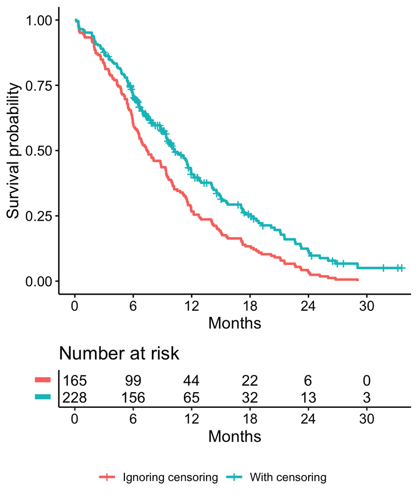

## Comparing survival times between groups

- We can conduct between-group significance tests using a log-rank test
- The log-rank test equally weights observations over the entire follow-up time and is the most common way to compare survival times between groups
- There are versions that more heavily weight the early or late follow-up that could be more appropriate depending on the research question (see `?survdiff` for different test options)

We get the log-rank p-value using the `survdiff` function. For example, we can test whether there was a difference in survival time according to sex in the `lung` data

```r
survdiff(Surv(time, status) ~ sex, data = lung)
```

```
## Call:
## survdiff(formula = Surv(time, status) ~ sex, data = lung)
##
##         N Observed Expected (O-E)^2/E (O-E)^2/V
## sex=1 138      112     91.6      4.55      10.3
## sex=2  90       53     73.4      5.68      10.3
##
##  Chisq= 10.3  on 1 degrees of freedom, p= 0.001
```

## Extracting information from a survdiff object

It’s actually a bit cumbersome to extract a p-value from the results of `survdiff`. Here’s a line of code to do it

```r
sd <- survdiff(Surv(time, status) ~ sex, data = lung)
1 - pchisq(sd$chisq, length(sd$n) - 1)
```

```
## [1] 0.001311165
```

Or there is the `sdp` function in the `ezfun` package, which you can install using `devtools::install_github("zabore/ezfun")`. It returns a formatted p-value

```r
ezfun::sdp(sd)
```

```
## [1] 0.001
```